# Healthcare Costs

To learn more about Quarto websites visit https://quarto.org/docs/websites.

## **Research Question:**

*Research Question 1:*

How does a health plan’s restriction index (RI) affect the average cost per prescription, and is this relationship affected by the percentage of generic substitution (GS)?

*Research Question 2:*

To what extent do demographic factors such as average age of members (AGE) and percentage of female members (F) contribute to differences in drug costs among health plans?

## **Motivation:**

For this data set, we explore the impact of factors related to healthcare costs on its impact. Understanding the interactions in the data is critical to interpreting the dynamics of costs associated with prescription drugs. First, we explore the relationship between revealed restriction indices (RIs) and generic drug use in health plans. The question of whether the impact of restriction indices on drug costs depends on how often health plans choose generic alternatives is explored and analyzed. Second, another interesting direction for analysis is demographics. This part of the study on the impact of characteristics such as the average age of Medicare plan members and the percentage of female members on prescription drug costs aims to provide a more comprehensive understanding of the factors that influence health care costs, making the analysis of this data set more holistic and enlightening.

## **Hypothesis:**

*Hypothesis 1:*

The relationship between the restriction index (RI) and average drug costs is affected by the percentage of generic substitution (GS). I hypothesize that health plans with higher GS percentages will have a weaker positive correlation between RI and drug costs compared to health plans with lower GS percentages.

*Hypothesis 2*:

Medicare plans with older average member ages will have higher drug costs. And Medicare plans with a higher percentage of female members may show higher drug costs.

## **Understanding and Description of the data:**

(the following text is directly from https://rdrr.io/rforge/alr4/man/drugcost.html)

“These data are to try to understand the effect of health plan characteristics on drug costs. Health plans vary in size, given as member months. Some plans use generic drugs more than others. All differ on copayments. Some have strong restrictions on which drugs can be dispensed value of RI=0 means that all drugs are dispensed, RI=100 means that only one per category is avaiable. The goal is to determine the terms that are related to cost, and in particular to understand the role of GS and RI in determining cost.

**COST:** Ave. cost to plan for 1 prescription for 1 day

**RXPM:** Number of prescriptions per member per year

**GS:** Percent generic substitution, number between 0 (no substitution) to 100 (always use generic substitute)

**RI:** Restrictiveness index (0=none, 100=total)

**COPAY:** Average Rx copayment

**AGE:** Average age of member

**F:** Percent female members

**MM:** Member months, a measure of the size of the plan” (drugcost: Drug cost.

In [alr4](https://rdrr.io/rforge/alr4/))

The dataset includes information on drug costs, prescriptions per member, generic substitution percentages, restrictiveness indices, copayments, average member ages, percentages of female members, and member months.

- Response Variable: COST
- Explanatory Variables: RXPM, GS, RI, COPAY, AGE, F, MM

# Display the Data:

```r
library(alr4)
data(drugcost, package = "alr4")
summary(drugcost)
```

```
      COST            RXPM              GS              RI
 Min.   :0.990   Min.   : 2.800   Min.   :16.00   Min.   : 0.3
 1st Qu.:1.160   1st Qu.: 5.200   1st Qu.:37.00   1st Qu.: 7.0
 Median :1.230   Median : 6.100   Median :40.00   Median :12.9
 Mean   :1.233   Mean   : 5.972   Mean   :39.24   Mean   :15.7
 3rd Qu.:1.340   3rd Qu.: 7.000   3rd Qu.:42.00   3rd Qu.:21.3
 Max.   :1.380   Max.   :10.700   Max.   :50.00   Max.   :45.6
     COPAY             AGE              F               MM
 Min.   : 4.130   Min.   :25.20   Min.   :49.00   Min.   :    491
 1st Qu.: 5.270   1st Qu.:28.50   1st Qu.:51.40   1st Qu.:  73380
 Median : 5.710   Median :29.10   Median :52.30   Median : 303312
 Mean   : 6.168   Mean   :29.09   Mean   :52.37   Mean   : 410992
 3rd Qu.: 6.270   3rd Qu.:29.80   3rd Qu.:53.40   3rd Qu.: 591456
 Max.   :10.870   Max.   :32.40   Max.   :57.20   Max.   :1388605
```

```r
names(drugcost)
```

```
[1] "COST"  "RXPM"  "GS"    "RI"    "COPAY" "AGE"   "F"     "MM"
```

```r
str(drugcost)
```

```
'data.frame':   29 obs. of  8 variables:
 $ COST : num  1.34 1.34 1.38 1.22 1.08 1.16 1.25 1.2 1.1 1.04 ...
 $ RXPM : num  4.2 5.4 7 7.1 3.5 7.2 10.7 7.6 7.2 6.6 ...
 $ GS   : int  36 37 37 40 40 46 40 43 45 42 ...
 $ RI   : num  45.6 45.6 45.6 23.6 23.6 22.3 22.3 21.3 20 20 ...
 $ COPAY: num  10.87 8.66 8.12 5.89 6.05 ...
 $ AGE  : num  29.7 29.7 29.7 28.7 28.7 29.1 29.1 29.8 32.4 29.8 ...
 $ F    : num  52.3 52.3 52.3 53.4 53.4 52.2 52.2 51.6 50.8 50 ...
 $ MM   : int  1158096 1049892 96168 407268 13224 303312 720 73380 513266 1388605 ...
```

```r
head(drugcost)
```

```
    COST RXPM GS   RI COPAY  AGE    F      MM
MN1 1.34  4.2 36 45.6 10.87 29.7 52.3 1158096
MN2 1.34  5.4 37 45.6  8.66 29.7 52.3 1049892
MN3 1.38  7.0 37 45.6  8.12 29.7 52.3   96168
GA  1.22  7.1 40 23.6  5.89 28.7 53.4  407268
GA2 1.08  3.5 40 23.6  6.05 28.7 53.4   13224
AZ1 1.16  7.2 46 22.3  5.05 29.1 52.2  303312
```

# Data Visualization:

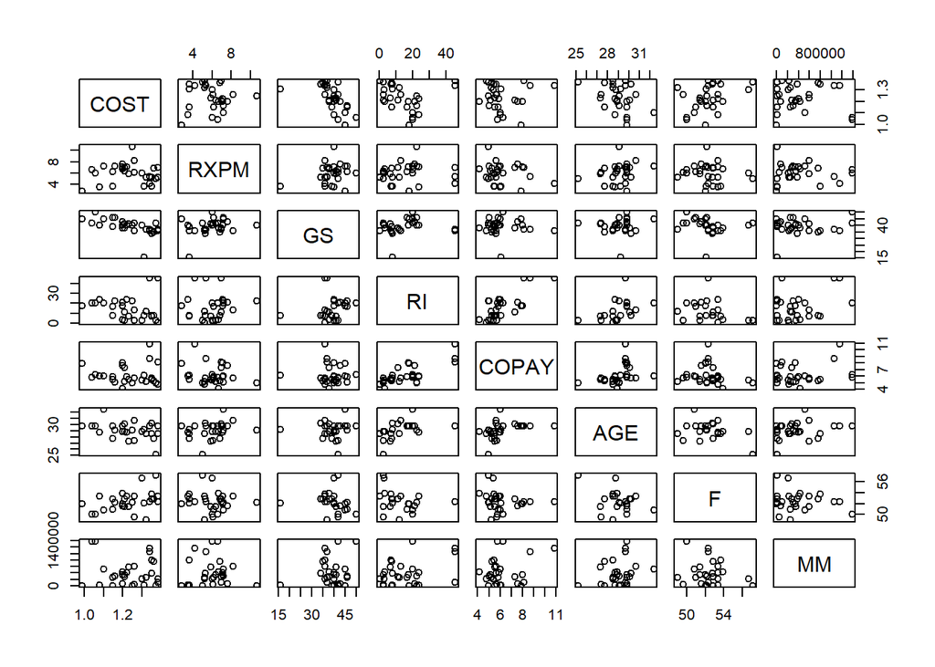

```r
#this graph examine pairwise relationships between variables.

library(corrplot)
pairs(drugcost[, c("COST", "RXPM", "GS", "RI", "COPAY", "AGE", "F", "MM")])
```

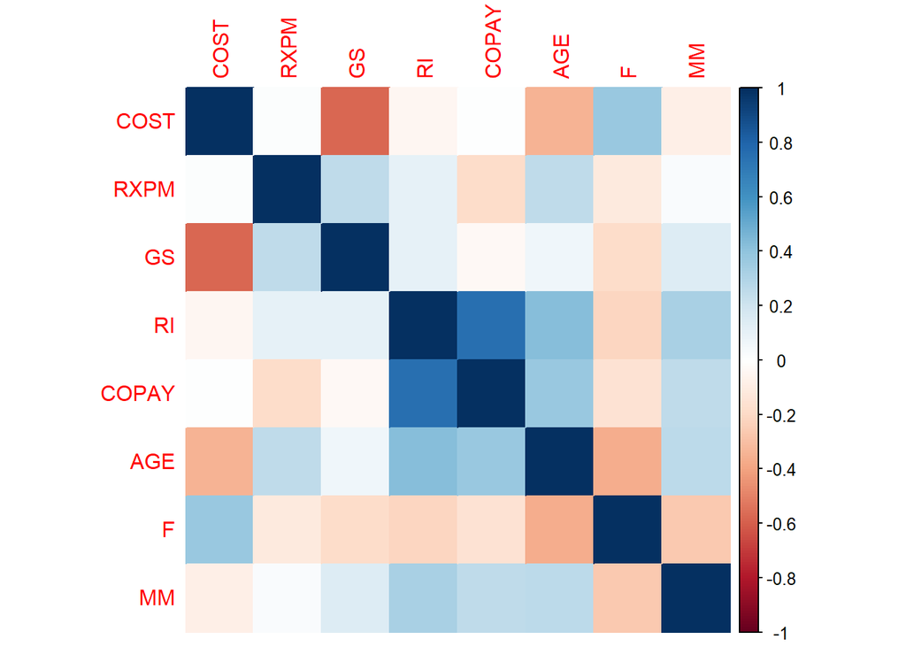

```r
cor_matrix <- cor(drugcost[, c("COST", "RXPM", "GS", "RI", "COPAY", "AGE", "F", "MM")])
corrplot(cor_matrix, method = "color")
```

This heat map explains the correlation values between specific variables for each cell.

Color scale: Positive correlations are usually colored blue and negative correlations are colored red. Strength: Darker colors indicate stronger correlations.

Positive correlation: Values close to 1 indicate a strong positive linear relationship.

Negative correlation: Values close to -1 indicate a strong negative linear relationship.

No correlation: Values close to 0 indicate a weak or no linear relationship.

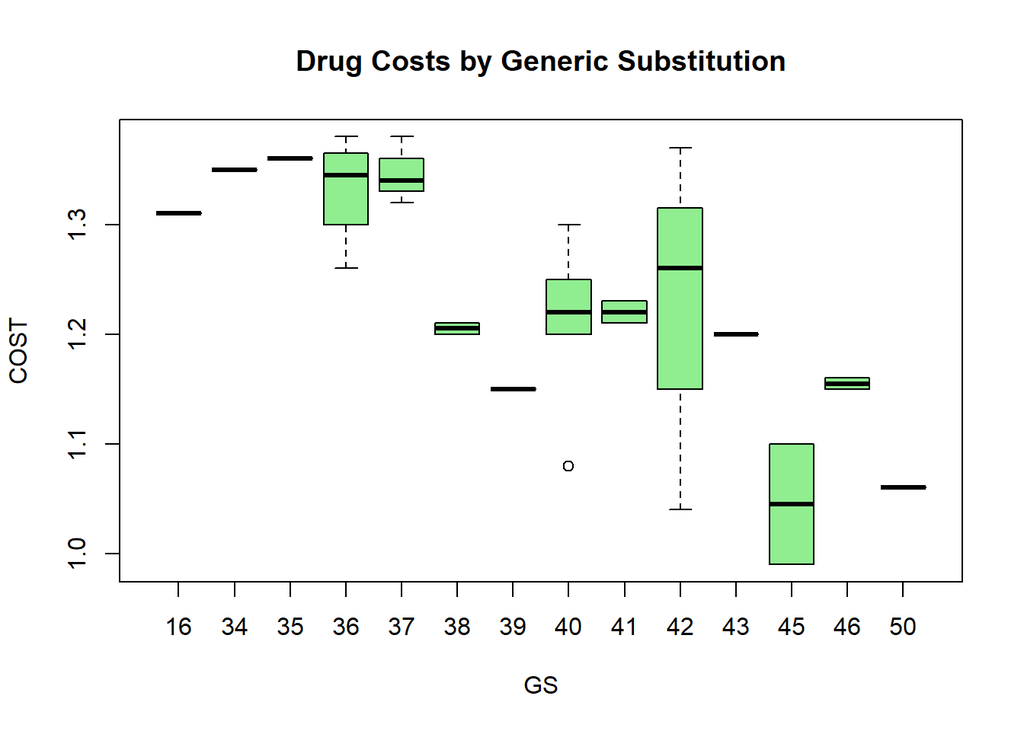

```r
boxplot(COST ~ GS, data = drugcost, main = "Drug Costs by Generic Substitution", col = "lightgreen")
```

For boxplot that the outliers represent data points worthy of attention.

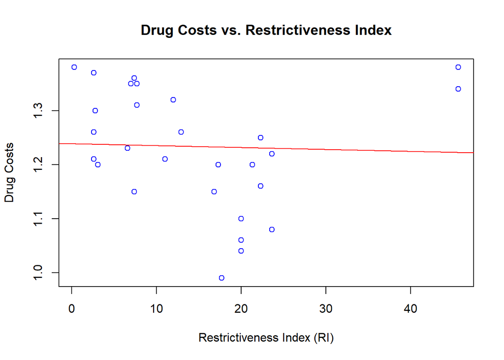

```r
# Scatter plot with regression line
plot(drugcost$RI, drugcost$COST, main = "Drug Costs vs. Restrictiveness Index",
     xlab = "Restrictiveness Index (RI)", ylab = "Drug Costs", col = "blue")
abline(lm(COST ~ RI, data = drugcost), col = "red")
```

From this graph, we can see that the regression assumptions is not violated, because this line is straight enough. Points are randomly distributed.

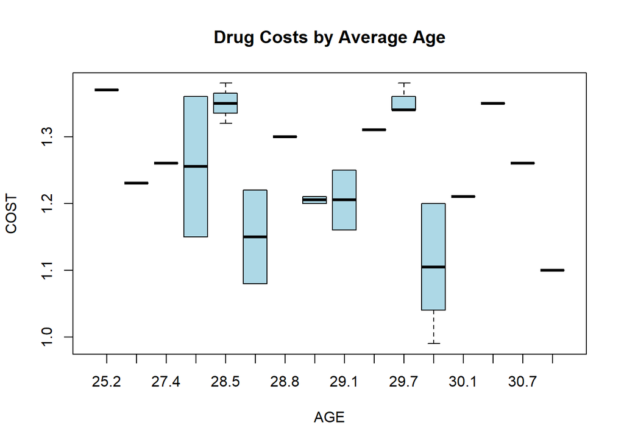

```r
boxplot(COST ~ AGE, data = drugcost, main = "Drug Costs by Average Age", col = "lightblue")
```

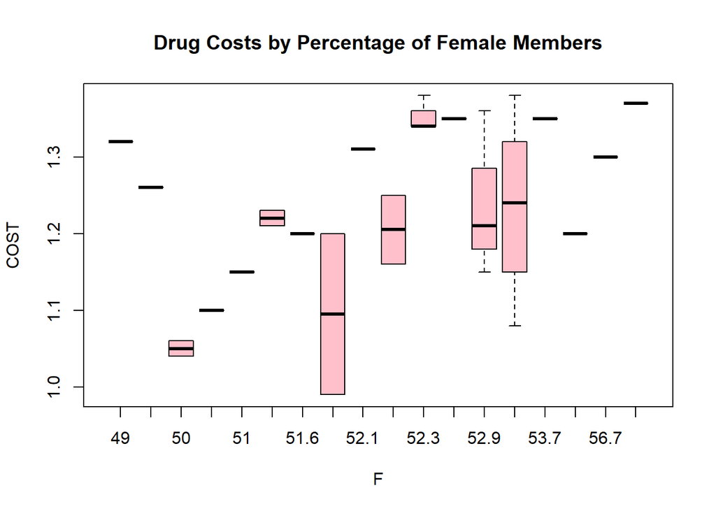

```r
boxplot(COST ~ F, data = drugcost, main = "Drug Costs by Percentage of Female Members", col = "pink")
```

# Data Analysis:

### test the hypothesis 1:

```r
library(MASS)
data(drugcost, package = "alr4")

model <- lm(COST ~ . , data = drugcost)

summary(model)
```

```
Call:
lm(formula = COST ~ ., data = drugcost)

Residuals:
      Min        1Q    Median        3Q       Max
-0.142888 -0.050521 -0.003367  0.047232  0.122523

Coefficients:
              Estimate Std. Error t value Pr(>|t|)
(Intercept)  1.851e+00  7.636e-01   2.424 0.024488 *
RXPM         2.241e-02  1.100e-02   2.037 0.054483 .
GS          -1.137e-02  2.830e-03  -4.018 0.000622 ***
RI           3.341e-04  2.089e-03   0.160 0.874468
COPAY        1.472e-02  1.870e-02   0.787 0.439791
AGE         -3.754e-02  1.491e-02  -2.517 0.020012 *
F            1.297e-02  9.712e-03   1.335 0.196148
MM           2.908e-08  4.163e-08   0.699 0.492505
---
Signif. codes:  0 '***' 0.001 '**' 0.01 '*' 0.05 '.' 0.1 ' ' 1

Residual standard error: 0.08276 on 21 degrees of freedom
Multiple R-squared:  0.5758,    Adjusted R-squared:  0.4344
F-statistic: 4.072 on 7 and 21 DF,  p-value: 0.00572
```

```r
# Conduct hypothesis testing for Hypothesis 1
interaction_model <- lm(COST ~ RI * GS , data = drugcost)

anova(model, interaction_model)
```

```
Analysis of Variance Table

Model 1: COST ~ RXPM + GS + RI + COPAY + AGE + F + MM
Model 2: COST ~ RI * GS
  Res.Df     RSS Df  Sum of Sq      F Pr(>F)
1     21 0.14383
2     25 0.15293 -4 -0.0091004 0.3322 0.8532
```

### test the hypothesis 2:

```r
#model for average member age
age_model <- lm(COST ~ AGE, data = drugcost)

anova(model, age_model)
```

```
Analysis of Variance Table

Model 1: COST ~ RXPM + GS + RI + COPAY + AGE + F + MM
Model 2: COST ~ AGE
  Res.Df     RSS Df Sum of Sq      F  Pr(>F)
1     21 0.14383
2     27 0.29778 -6  -0.15395 3.7461 0.01084 *
---
Signif. codes:  0 '***' 0.001 '**' 0.01 '*' 0.05 '.' 0.1 ' ' 1
```

```r
#model for percentage of female members (F)
female_model <- lm(COST ~ F, data = drugcost)

anova(model, female_model)
```

```
Analysis of Variance Table

Model 1: COST ~ RXPM + GS + RI + COPAY + AGE + F + MM
Model 2: COST ~ F
  Res.Df     RSS Df Sum of Sq      F  Pr(>F)
1     21 0.14383
2     27 0.29113 -6   -0.1473 3.5844 0.01325 *
---
Signif. codes:  0 '***' 0.001 '**' 0.01 '*' 0.05 '.' 0.1 ' ' 1
```

Move to the female model data, Observation from that the p-value (Pr(>F)) for this model is 0.01325, which is less than the significance level of 0.05. we reject the null hypothesis as well. It also responds the hypothesis that the female gender playing a role to the variation in drug costs.

```r
r_squared <- c(
  Interaction_Model = summary(interaction_model)$adj.r.squared,
  Age_Model = summary(age_model)$adj.r.squared,
  Female_Model = summary(female_model)$adj.r.squared
)

r_squared
```

```
Interaction_Model         Age_Model      Female_Model
       0.49481826        0.08921094        0.10954400
```

```r
# P-value for Interaction_Model
summary(interaction_model)$coefficients[, "Pr(>|t|)"]
```

```
 (Intercept)           RI           GS        RI:GS
1.760326e-05 1.702647e-03 2.935737e-01 1.698916e-03
```

```r
# P-value for Age_Model
summary(age_model)$coefficients[, "Pr(>|t|)"]
```

```
 (Intercept)          AGE
7.118312e-05 6.358485e-02
```

```r
# P-value for Female_Model
summary(female_model)$coefficients[, "Pr(>|t|)"]
```

```
(Intercept)           F
 0.97553382  0.04443384
```

```r
rsq <- function(fit) summary(fit)$r.squared
adj_rsq <- function(fit) summary(fit)$adj.r.squared
PRESS <- function(fit) {
    pr <- residuals(fit)/(1 - lm.influence(fit)$hat)
    sum(pr^2)
}
```

```r
library(magrittr)

models_1 <- list(age_model, female_model, interaction_model)
data.frame(models_1 = c('age_model', 'female_model', 'interaction_model'),
           rsq = sapply(models_1, rsq),
           adj.rsq = sapply(models_1, adj_rsq),
           PRESS = sapply(models_1, PRESS),
           AIC = sapply(models_1, AIC),
           BIC = sapply(models_1, BIC)
) %>%
  print()
```

```
           models_1       rsq    adj.rsq     PRESS       AIC       BIC
1         age_model 0.1217391 0.08921094 0.3304414 -44.48386 -40.38197
2      female_model 0.1413460 0.10954400 0.3333067 -45.13861 -41.03673
3 interaction_model 0.5489449 0.49481826 0.2457240 -59.80813 -52.97165
```

Explanation for selecting the final model:

I created these three models: age, female, and interaction and compared their adjusted r-squared, AIC, BIC, and diagnostic statistics to confirm which one was the best fit. Because in the face of these data, I found that the interaction model performed best: its r-squared was larger than the other two sets of models, and its AIC/BIC was smaller than the other two sets of models. Its sum of squared prediction residuals is also smaller than the other two models.

```r
final_model <- interaction_model
summary(final_model)
```

```
Call:
lm(formula = COST ~ RI * GS, data = drugcost)

Residuals:
     Min       1Q   Median       3Q      Max
-0.14753 -0.05277  0.01135  0.05194  0.12410

Coefficients:
             Estimate Std. Error t value Pr(>|t|)
(Intercept)  1.049876   0.198442   5.291 1.76e-05 ***
RI           0.049934   0.014208   3.514   0.0017 **
GS           0.005703   0.005316   1.073   0.2936
RI:GS       -0.001322   0.000376  -3.515   0.0017 **
---
Signif. codes:  0 '***' 0.001 '**' 0.01 '*' 0.05 '.' 0.1 ' ' 1

Residual standard error: 0.07821 on 25 degrees of freedom
Multiple R-squared:  0.5489,    Adjusted R-squared:  0.4948
F-statistic: 10.14 on 3 and 25 DF,  p-value: 0.0001493
```

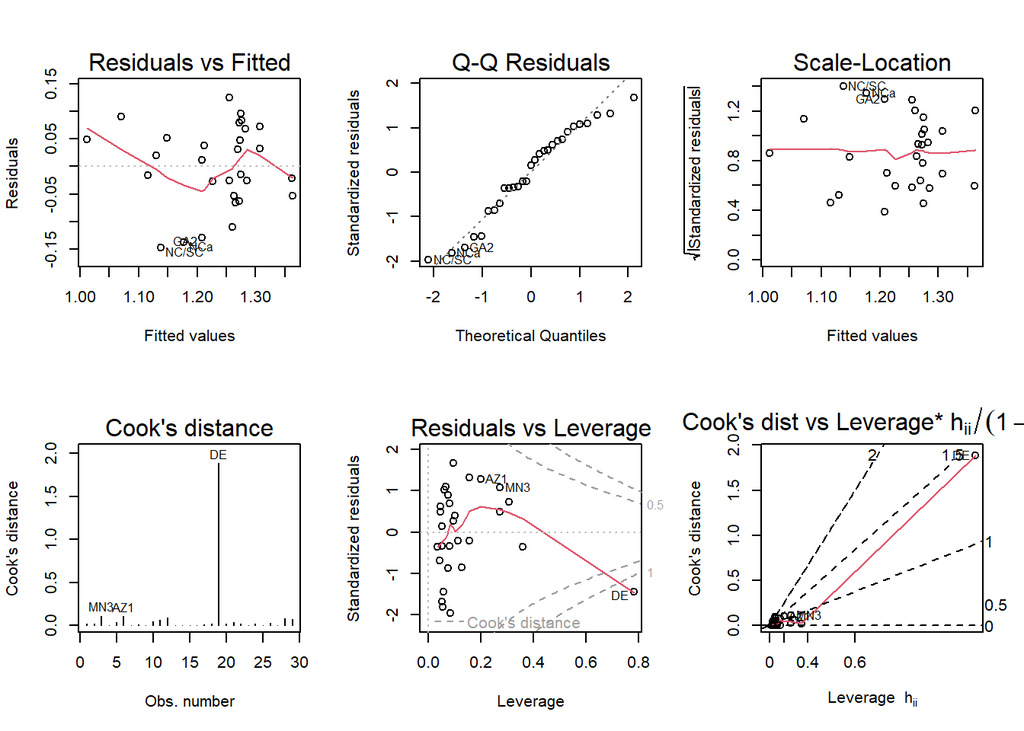

```r
par(mfrow = c(2 ,3))
plot(final_model, which = 1:6)
```

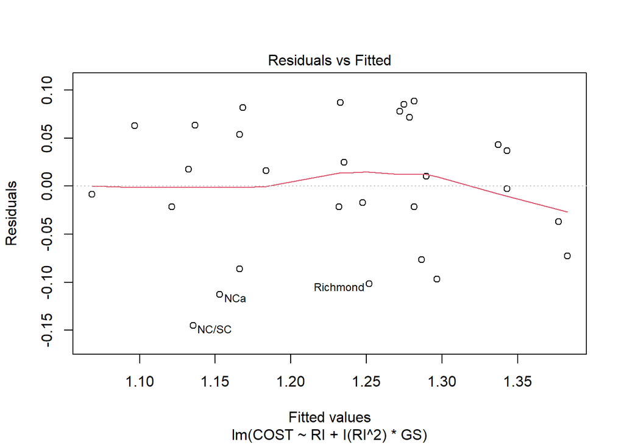

```r
final <- lm(COST ~ RI + I(RI^2) * GS, data = drugcost)
plot(final, which = 1)
```

We need to adjust this line to be horizontal. After adjustment, we can see that this line is very close to horizontal.

**Residuals vs. Fitted Values:**

A random scatter of points around the horizontal axis, so it is homoscedasticity.

**Normal Q-Q (Quantile-Quantile) Plot:**

**Scale-Location Plot:**

A horizontal line so it ishomoscedasticity.

**Cook’s Distance Plot:**

It significantly impact the regression results because it has extreme point.

**Residuals vs. Leverage Plot:**

# Key Finding:

For further research, we can study other explanatory Variables: RXPM, GS, RI, COPAY, MM to explore the relationship with the response Variable: COST, will get more outstanding findings I believe.